# Lab3_UnivariateLinearRegression

## Univariate Linear Regression on the California Housing Prices Dataset

### Univariate Linear Regression Model

```python
import pandas as pd
import matplotlib.pyplot as plt
import seaborn as sns

from sklearn.linear_model import LinearRegression
from sklearn.metrics import mean_squared_error, mean_absolute_error
```

A linear regression between the median house value (dependent variable) and each of the following independent variables. Three models, one for each independent variable:

① Median Income

```python
housing = pd.read_csv("data/housing.csv")
```

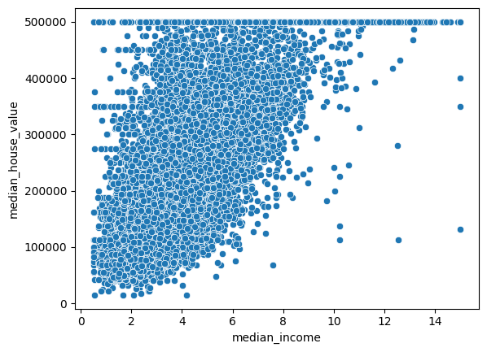

```python
sns.scatterplot(x="median_income", y="median_house_value", data=housing)
```

② Population

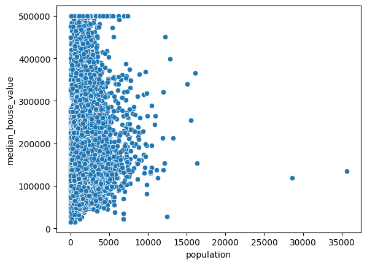

```python
sns.scatterplot(x="population", y="median_house_value", data=housing)
```

③ Number Of Households

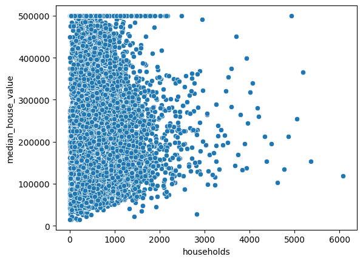

```python
sns.scatterplot(x="households", y="median_house_value", data=housing)
```

## ➊ Framing the Problem

#### ➼ This report's objective is to analyze the California Housing Prices dataset using Univariate Linear Regression. Our specific goal is to construct three distinct models, each concentrating on a distinct independent variable ‣ the median income, the population, and the number of households. Finding the correlation between these distinct factors and the median house value is the goal.

## ➋ Getting the Data

### ➼ [California Housing Prices Data](https://www.kaggle.com/datasets/camnugent/california-housing-prices)

## ➌ Exploratory Data Analysis (EDA):

##### ○ Explore statistics

```python
housing.describe()
```

|  | longitude | latitude | housing_median_age | total_rooms | total_bedrooms | population | households | median_income | median_house_value |
| --- | --- | --- | --- | --- | --- | --- | --- | --- | --- |
| count | 20640.000000 | 20640.000000 | 20640.000000 | 20640.000000 | 20433.000000 | 20640.000000 | 20640.000000 | 20640.000000 | 20640.000000 |
| mean | -119.569704 | 35.631861 | 28.639486 | 2635.763081 | 537.870553 | 1425.476744 | 499.539680 | 3.870671 | 206855.816909 |
| std | 2.003532 | 2.135952 | 12.585558 | 2181.615252 | 421.385070 | 1132.462122 | 382.329753 | 1.899822 | 115395.615874 |
| min | -124.350000 | 32.540000 | 1.000000 | 2.000000 | 1.000000 | 3.000000 | 1.000000 | 0.499900 | 14999.000000 |
| 25% | -121.800000 | 33.930000 | 18.000000 | 1447.750000 | 296.000000 | 787.000000 | 280.000000 | 2.563400 | 119600.000000 |
| 50% | -118.490000 | 34.260000 | 29.000000 | 2127.000000 | 435.000000 | 1166.000000 | 409.000000 | 3.534800 | 179700.000000 |
| 75% | -118.010000 | 37.710000 | 37.000000 | 3148.000000 | 647.000000 | 1725.000000 | 605.000000 | 4.743250 | 264725.000000 |
| max | -114.310000 | 41.950000 | 52.000000 | 39320.000000 | 6445.000000 | 35682.000000 | 6082.000000 | 15.000100 | 500001.000000 |

##### ○ Describe the 4 variables used in this lab. Review the range of the data for each variable, and other issues you notice

```python
housing.median_house_value
```

```
0        452600.0
1        358500.0
2        352100.0
3        341300.0
4        342200.0
           ...
20635     78100.0
20636     77100.0
20637     92300.0
20638     84700.0
20639     89400.0
Name: median_house_value, Length: 20640, dtype: float64
```

```python
housing.median_income
```

```
0        8.3252
1        8.3014
2        7.2574
3        5.6431
4        3.8462
          ...
20635    1.5603
20636    2.5568
20637    1.7000
20638    1.8672
20639    2.3886
Name: median_income, Length: 20640, dtype: float64
```

```python
housing.population
```

```
0         322.0
1        2401.0
2         496.0
3         558.0
4         565.0
          ...
20635     845.0
20636     356.0
20637    1007.0
20638     741.0
20639    1387.0
Name: population, Length: 20640, dtype: float64
```

```python
housing.households
```

```
0         126.0
1        1138.0
2         177.0
3         219.0
4         259.0
          ...
20635     330.0
20636     114.0
20637     433.0
20638     349.0
20639     530.0
Name: households, Length: 20640, dtype: float64
```

##### ○ Create three Seaborn scatter plots of median house value vs. median income, population and number of households.

```python
housing_preprocessed = housing[housing.median_house_value != 500001]
```

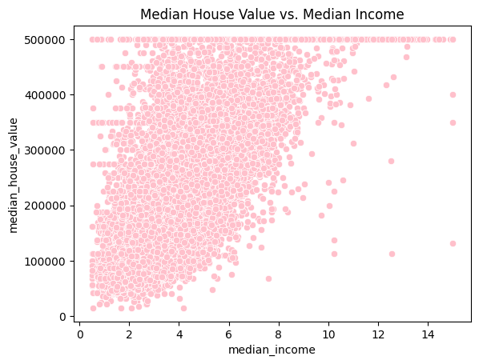

```python
sns.scatterplot(x="median_income", y="median_house_value", data=housing, color="pink")
plt.title('Median House Value vs. Median Income')
```

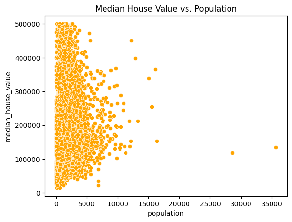

```python
sns.scatterplot(x="population", y="median_house_value", data=train, color="orange")
plt.title('Median House Value vs. Population')
```

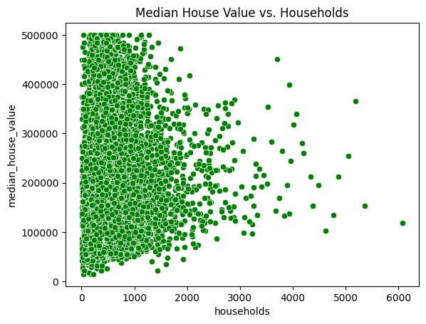

```python
sns.scatterplot(x="households", y="median_house_value", data=train, color="green")
plt.title('Median House Value vs. Households')
```

### ➍ Run three linear regressions (fitting) between :

median house value vs. median income

median house value vs. population

median house value vs. number of households.

```python
# median house value vs. median income
model1 = LinearRegression().fit(housing[['median_income']], housing['median_house_value'])

# median house value vs. population
model2 = LinearRegression().fit(housing[['population']], housing['median_house_value'])

# median house value vs. number of households
model3 = LinearRegression().fit(housing[['households']], housing['median_house_value'])
```

Plot the resulting line on top of the scatter data for each of the three models

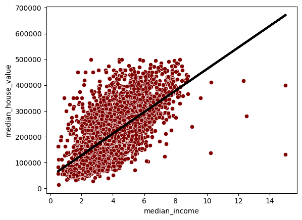

```python
sns.scatterplot(x="median_income", y="median_house_value", data=test, color="maroon")
plt.plot(test[["median_income"]], model1.predict(test[["median_income"]]), color="black", linewidth=3)
plt.show()
```

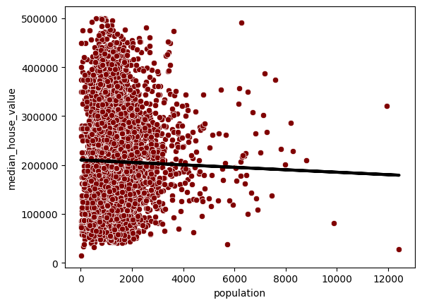

```python
sns.scatterplot(x="population", y="median_house_value", data=test, color="maroon")
plt.plot(test[["population"]], model2.predict(test[["population"]]), color="black", linewidth=3)
```

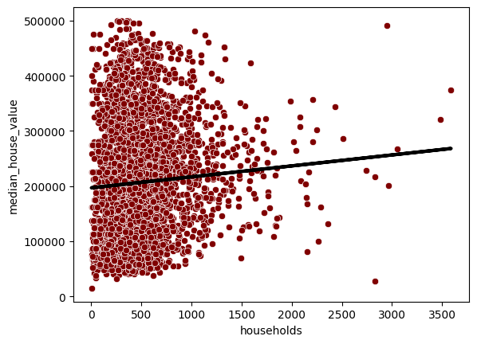

```python
sns.scatterplot(x="households", y="median_house_value", data=test, color="maroon")
plt.plot(test[["households"]], model3.predict(test[["households"]]), color="black", linewidth=3)
```